# Session 8.1 KNN: Classifying iPlayer users

# 8 Using KNN with PCA

As I mentioned in class the performance of KNN is very sensitive to the number of features in the data. This may especially be a concern when we have a lot of features. If we are dealing with large data sets, we might want to reduce the dimension of the data set to improve performance. Next I find the principal components of BBC data and then implement KNN using these components instead of the original variables.

## 8.1 Running PCA on the BBC Data

```r
#Let's delete the nonnumeric column and the dependent variable before we apply PCA
combined_nn_pca<-userBasedData_clean%>% select(-c(watched_in_Feb))
####Let's first generate training and test data sets
#I will use the same seed we used for base knn. This allows me to do a fair comparison below.
set.seed(1212)

train_test_split <- initial_split(combined_nn_pca, prop = 0.75) #training set contains 75% of the data
# Create the training dataset
combined_train_pca <- training(train_test_split)
# Create the test dataset
combined_test_pca <- testing(train_test_split)
head(combined_test_pca)
```

```
##      weekday   weekend Afternoon  Day Evening Night Children Comedy     Drama
## 3  1.0000000 0.0000000      0.00 1.00     0.0     0        0      0   0.00000
## 8  1.0000000 0.0000000      0.00 0.00     1.0     0        0      0   0.00000
## 10 0.6666667 0.3333333      0.00 0.00     1.0     0        0      0  33.33333
## 11 0.7500000 0.2500000      0.15 0.45     0.4     0        0      0   0.00000
## 12 0.0000000 1.0000000      0.00 0.00     1.0     0        0      0 100.00000
## 14 1.0000000 0.0000000      1.00 0.00     0.0     0        0      0  50.00000
##    Entertainment Factual Learning Music      News NoGenre RelEthics Sport
## 3              0       0        0     0 100.00000       0         0     0
## 8              0       0        0     0   0.00000       0         0   100
## 10             0       0        0     0  33.33333       0         0     0
## 11            10      30        0     0  50.00000       0         0     5
## 12             0       0        0     0   0.00000       0         0     0
## 14             0       0        0     0   0.00000       0         0    50
##     Weather per_al_Watched log_total_Time log_number_of_shows
## 3   0.00000              0      0.6239579           0.6931472
## 8   0.00000              0      1.0299765           0.0000000
## 10 33.33333              0      1.4167751           1.0986123
## 11  5.00000             35      6.1004420           2.9957323
## 12  0.00000              0      2.6661362           0.0000000
## 14  0.00000              0      0.6847705           0.6931472
```

```r
#Next find the principle components on training data
BBC.pca <- prcomp(combined_train_pca, center = TRUE,scale. = TRUE)
summary(BBC.pca)
```

```
## Importance of components:
##                           PC1     PC2     PC3     PC4     PC5     PC6     PC7
## Standard deviation     1.5180 1.43696 1.24765 1.15707 1.15128 1.11108 1.08668
## Proportion of Variance 0.1097 0.09833 0.07413 0.06375 0.06312 0.05879 0.05623
## Cumulative Proportion  0.1097 0.20806 0.28219 0.34594 0.40906 0.46784 0.52407
##                           PC8     PC9   PC10    PC11    PC12    PC13    PC14
## Standard deviation     1.0737 1.05024 1.0349 1.00770 1.00224 0.99395 0.96804
## Proportion of Variance 0.0549 0.05252 0.0510 0.04835 0.04783 0.04704 0.04462
## Cumulative Proportion  0.5790 0.63149 0.6825 0.73085 0.77868 0.82573 0.87035
##                           PC15    PC16    PC17    PC18      PC19      PC20
## Standard deviation     0.96059 0.92416 0.88358 0.40635 6.821e-14 1.532e-14
## Proportion of Variance 0.04394 0.04067 0.03718 0.00786 0.000e+00 0.000e+00
## Cumulative Proportion  0.91429 0.95496 0.99214 1.00000 1.000e+00 1.000e+00
##                             PC21
## Standard deviation     1.046e-14
## Proportion of Variance 0.000e+00
## Cumulative Proportion  1.000e+00
```

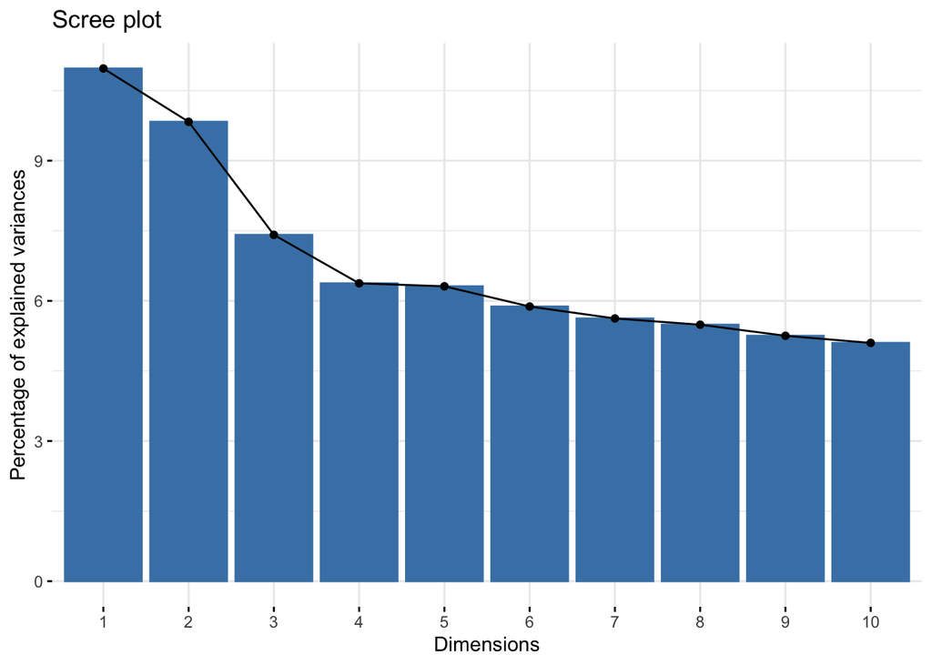

```r
#visualize the components using 'factoextra' library, which we also used in cluster analysis
suppressMessages(library(factoextra))
fviz_eig(BBC.pca)
```

```r
#Get the components for each record in training data
training_pca<-predict(BBC.pca,combined_train_pca)
#Choose a subset of the components.
pca_reduced_training<-data.frame(training_pca[,1:15])
#Copy the dependent variable.
pca_reduced_training$watched_in_Feb<-combined_train$watched_in_Feb
```

## 8.2 Running KNN with PCA data

Next I run KNN in the new data set. Steps are identical to those above.

```r
knnGrid_pca <-  expand.grid(k= seq(5,100 , by = 10))

fitPCA <- train(watched_in_Feb~., data=pca_reduced_training, method="knn", metric="ROC", trControl=control,tuneGrid = knnGrid_pca)
# display results
print(fitPCA)
```

```
## k-Nearest Neighbors
##
## 7013 samples
##   15 predictor
##    2 classes: 'No', 'Yes'
##
## No pre-processing
## Resampling: Cross-Validated (5 fold)
## Summary of sample sizes: 5610, 5610, 5611, 5610, 5611
## Resampling results across tuning parameters:
##
##   k   ROC        Sens       Spec
##    5  0.7173641  0.6447591  0.6998696
##   15  0.7495251  0.6787421  0.7092568
##   25  0.7555350  0.6815748  0.7220339
##   35  0.7574323  0.6674199  0.7282920
##   45  0.7592947  0.6582954  0.7340287
##   55  0.7597633  0.6501099  0.7371578
##   65  0.7609432  0.6460120  0.7371578
##   75  0.7611627  0.6419210  0.7408083
##   85  0.7609241  0.6441212  0.7457627
##   95  0.7606676  0.6353117  0.7512386
##
## ROC was used to select the optimal model using the largest value.
## The final value used for the model was k = 75.
```

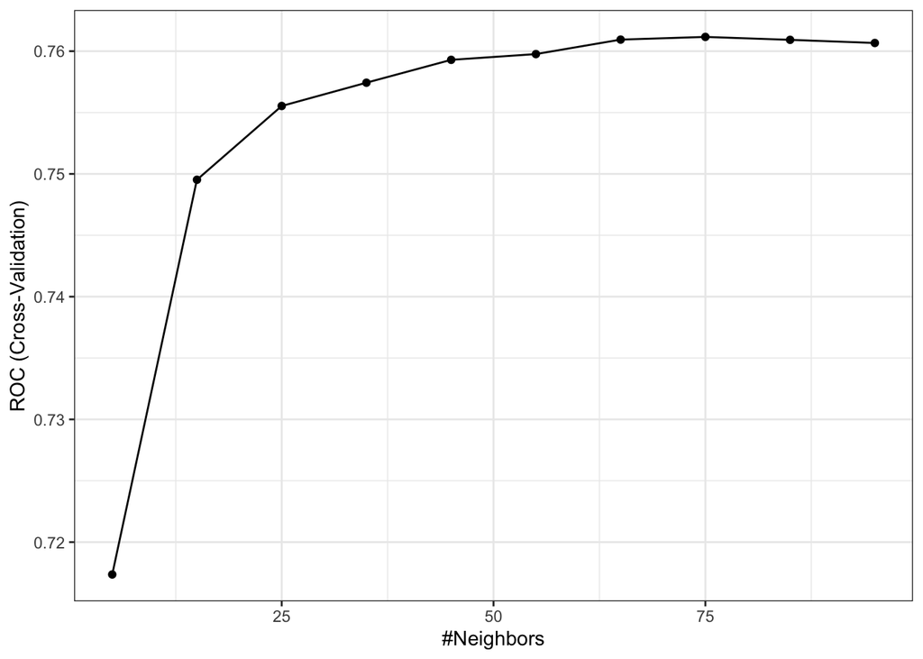

```r
ggplot(fitPCA) + theme_bw()
```

```r
###Let's test the performance of the best model on the test data
pca_reduced_testPCA<-predict(BBC.pca,combined_test_pca)
#Choose a subset of the components.
pca_reduced_testing<-data.frame(pca_reduced_testPCA[,1:15])
#Copy the dependent variable.
pca_reduced_testing$watched_in_Feb<-combined_test$watched_in_Feb

a<-predict(fitPCA, newdata = pca_reduced_testing, cutoff = .5 )

###Examine the confusion matrix
confusionMatrix(data = a,reference = pca_reduced_testing$watched_in_Feb)
```

```
## Confusion Matrix and Statistics
##
##           Reference
## Prediction  No Yes
##        No  702 330
##        Yes 352 954
##
##                Accuracy : 0.7083
##                  95% CI : (0.6894, 0.7267)
##     No Information Rate : 0.5492
##     P-Value [Acc > NIR] : <2e-16
##
##                   Kappa : 0.4098
##
##  Mcnemar's Test P-Value : 0.4213
##
##             Sensitivity : 0.6660
##             Specificity : 0.7430
##          Pos Pred Value : 0.6802
##          Neg Pred Value : 0.7305
##              Prevalence : 0.4508
##          Detection Rate : 0.3003
##    Detection Prevalence : 0.4414
##       Balanced Accuracy : 0.7045
##
##        'Positive' Class : No
##
```

```r
###Let's look at the ROC
a<-predict(fitPCA, newdata = pca_reduced_testing,type = "prob")[,2]
ROC <- roc(pca_reduced_testing$watched_in_Feb, a)
```

```r
# Plot the ROC curve
# Plot the ROC curve

g <- ggroc(ROC)
AUC_PCA=round(ROC$auc*100, digits=2)
AUC_PCA
```

```
## [1] 77.01
```

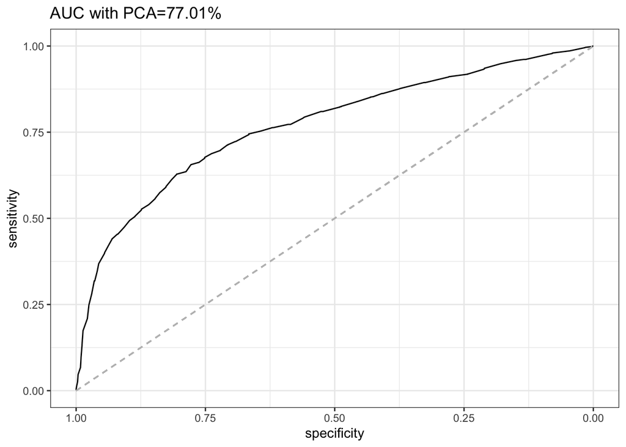

```r
g + theme_bw() +ggtitle(paste("AUC with PCA=",AUC_PCA,"%",sep="")) +
  geom_segment(aes(x = 1, xend = 0, y = 0, yend = 1), color="grey", linetype="dashed")
```

Did using PCA help improve the performance of KNN? Why or why not? How should we choose the number of PCA components we use with KNN? Write the code to implement your idea, see the last section in this document.

Finally let’s compare the performance of KNN models with and without PCA

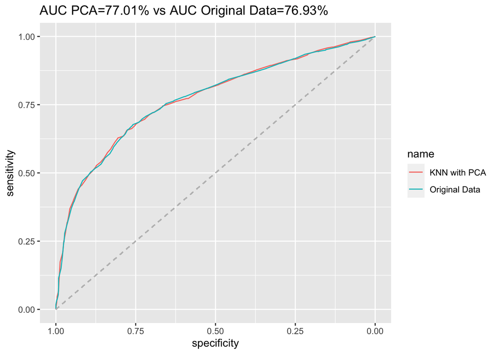

```r
g2 <- ggroc(list("KNN with PCA"=ROC, "Original Data"=ROC_knn))
g2+ggtitle(paste("AUC PCA=",AUC_PCA,"%"," vs AUC Original Data=",AUC_knn,"%",sep="" ))+geom_segment(aes(x = 1, xend = 0, y = 0, yend = 1), color="grey", linetype="dashed")
```

> Exercise: Re-fit a logistic regression model using all PCA components. How does it perform?